# Annotations

Ashwin Malshe

10/4/2022

We will use `economics` data set which comes bundled with `ggplot2`. Here is the variable description:

A data frame with 574 rows and 6 variables:

date - Month of data collection pce - personal consumption expenditures, in billions of dollars pop - total population, in thousands psavert - personal savings rate uempmed - median duration of unemployment, in weeks unemploy - number of unemployed in thousands

## Text annotations

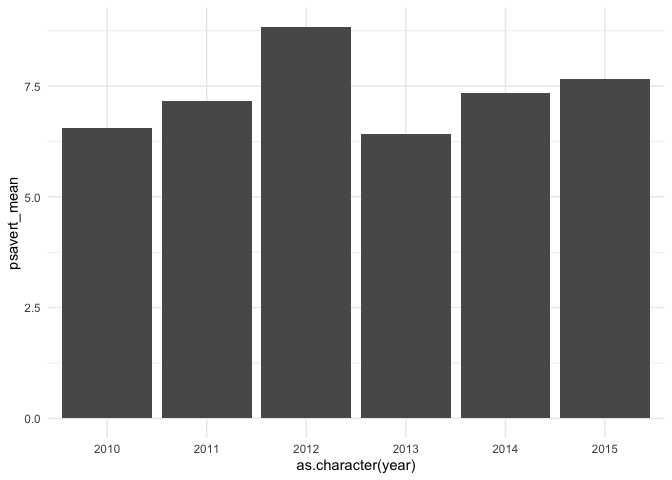

```r
p1 <- economics %>%
  mutate(year = lubridate::year(date)) %>%
  filter(year >= 2010) %>%
  group_by(year) %>%
  summarize(psavert_mean = mean(psavert, na.rm = TRUE),
            .groups = "drop") %>%
  ggplot(aes(x = as.character(year), y = psavert_mean)) +
  geom_col()

p1
```

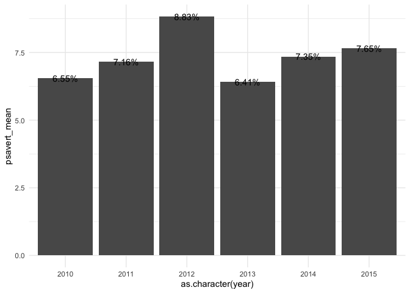

```r
p1 +
  geom_text(aes(label = scales::percent(psavert_mean/100, accuracy = 0.01)))
```

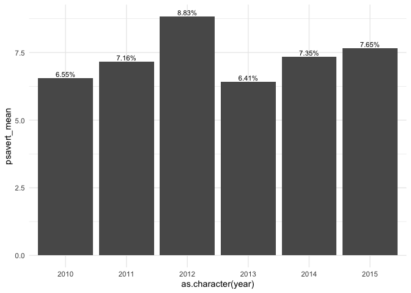

```r
p1 +
  geom_text(aes(label = scales::percent(psavert_mean/100, accuracy = 0.01)),
            vjust = -0.3, size = 3)
```

You can set y aesthetic to a constant, which will show the labels at the same height. You may include it inside `aes()` or outside. Here I include it outside the `aes()`.

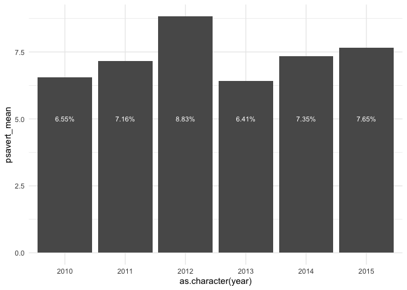

```r
p1 +
  geom_text(aes(label = scales::percent(psavert_mean/100, accuracy = 0.01)),
            y = 5, size = 3, color = "white")
```

## Adding annotations for only a few points

`geom_text()` will add text to all the points in the plot. However, often we need to annotate only a few points on the plot. For this purpose, `annotate_*()` functions come in handy.

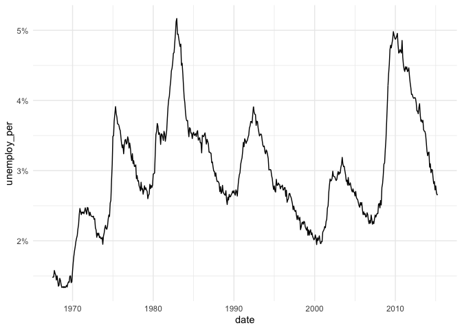

```r
p2 <- economics %>%
  mutate(unemploy_per = unemploy / pop) %>%
  ggplot(aes(date, unemploy_per)) +
  geom_line() +
  scale_y_continuous(labels = scales::percent)

p2
```

Annotate 2010 spike in the unemployment

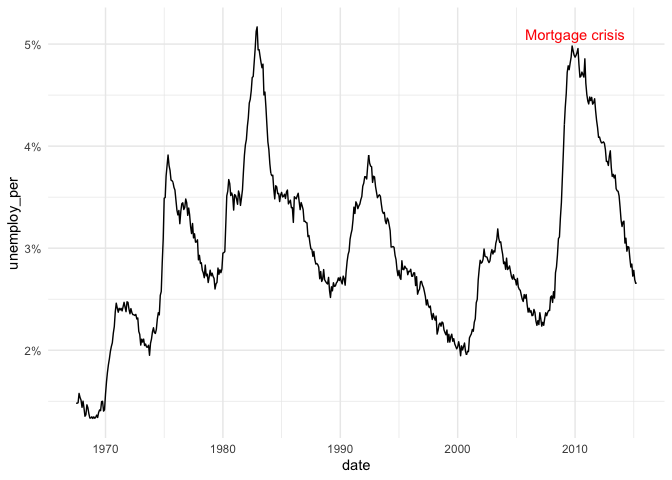

```r
p2 +
  annotate("text", label = "Mortgage crisis",
           x = as.Date("2010-01-01"), y = 0.051,
           color = "red")
```

## Image annotation

For annotating plots with images like `geom_text` we have to update the data set with the file path to those images. It’s a bit tedious and you should use it only if you really need to. The package for this is `ggimage` and the relevant geom is `geom_image()`. Read more about it here: https://yulab-smu.top/pkgdocs/ggimage.html

It’s far more common to use images to annotate only one point of a plot. For example, you may want to include a logo on the plot either in the background or in one corner. Here is how to do that:

Download UTSA logo (stacked) from here and save it in your project directory:

https://www.utsa.edu/marcomstudio/resources/logos-visual-identity/

Take a note of the file extension. If it is `.png` we will use `png` packages

[figure not shown]

```r
 economics %>%
  mutate(unemploy_per = unemploy / pop) %>%
  ggplot(aes(date, unemploy_per)) +
  annotation_raster(readPNG("UTSA_Logo_Website_UTSA_Logo_Stacked_Center.png"),
                    xmin = -Inf, xmax = Inf, ymin = 0.015, ymax = 0.05, interpolate = T) +
  geom_line(color = "#69be0f", size = 1) +
  scale_y_continuous(labels = scales::percent)
```

[figure not shown]

```r
 economics %>%
  mutate(unemploy_per = unemploy / pop) %>%
  ggplot(aes(date, unemploy_per)) +
  annotation_raster(readPNG("UTSA_Logo_Website_UTSA_Logo_Stacked_Center.png"),
                    xmin = as.Date("2000-01-01"), xmax = as.Date("2015-01-01"),
                    ymin = 0.015, ymax = 0.02, interpolate = T) +
  geom_line(color = "#69be0f", size = 1) +
  scale_y_continuous(labels = scales::percent)
```

## Use custom fonts with showtext

Finally, let’s use custom fonts using `showtext` package.

```r
font_add_google("Akronim", "akronim")
showtext_auto()
```

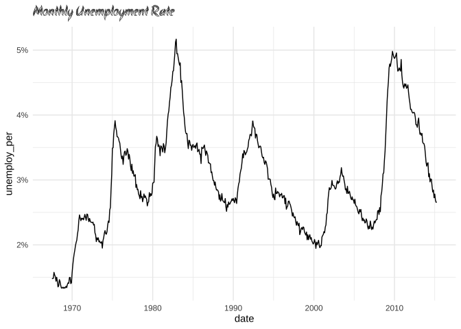

```r
p2 +
  labs(title = "Monthly Unemployment Rate") +
  theme(plot.title = element_text(family = "akronim", size = 16))
```